# Logistic regression

## Today’s data

The `pokemon_cleaned` dataset contains data on 896 Pokemon, including from Sword and Shield (generation 8), but does not include alternate forms. The dataset contains information on a Pokemon’s name, baseline battle statistics (base stats), and whether they are “legendary” (broadly defined). Pokemon are fantastic creatures with unique characteristics, and may be used to battle each other in combat. The battle-effectiveness of a Pokemon is in part determined by their “base stats,” which consist of HP (hit points), attack, defense, special attack, special defense, and speed. Some Pokemon are considered “legendary” Pokemon if they are exceptionally rare in some sense. Legendary Pokemon are often, but not always, more powerful than their non-legendary counterparts. The variables in the dataset are listed below:

- `n_dex_num`: a catalogue number of each Pokemon
- `name`: the name of the Pokemon
- `hp`, `atk`, `def`, `spa`, `spd`, `spe`: a Pokemon’s battle statistics (HP, attack, defense, special attack, special defense, and speed, respectively)
- `total`: the total base stats of the Pokemon
- `legendary`: whether the Pokemon is legendary

(Pokemon and Pokemon names are trademarks of Nintendo.)

## Non-continuous outcomes

In previous tutorials, we’ve focused on using linear regression as a tool to

- Make predictions about new observations
- Describe relationships
- Perform statistical inference

These examples have all had *continuous* response variables. But can we do similar tasks for **binary categorical** response variables too? Today’s goals are to predict whether a Pokemon is a legendary based on its base stats and describe the relationship between stats and *probability* of being legendary.

[figure not shown]

[figure not shown]

Suppose we have some hypothetical Pokemon with the following base stats. Would we classify them as legendary Pokemon based on these characteristics?

- Crapistat: HP = 55, ATK = 25, DEF = 30, SPA = 60, SPD = 50, SPE = 102
- Mediocra: HP = 90, ATK = 110, DEF = 130, SPA = 75, SPD = 80, SPE = 45
- Literally Dragonite: HP: 91, ATK: 134, DEF: 95, SPA: 100, SPD: 100, SPE: 80
- Broaken: HP = 104, ATK = 125, DEF = 105, SPA = 148, SPD = 102, SPE = 136

## Problems with linear models

Suppose we consider the following model for $p$, the probability of being a legendary Pokemon:
$${p} = \beta_0 + \beta_1HP + \beta_2ATK + \cdots + \beta_6\times SPE$$

1. What can go wrong using this model?

Let’s run this model and find out. Check out the residual plot from the linear model specified above:

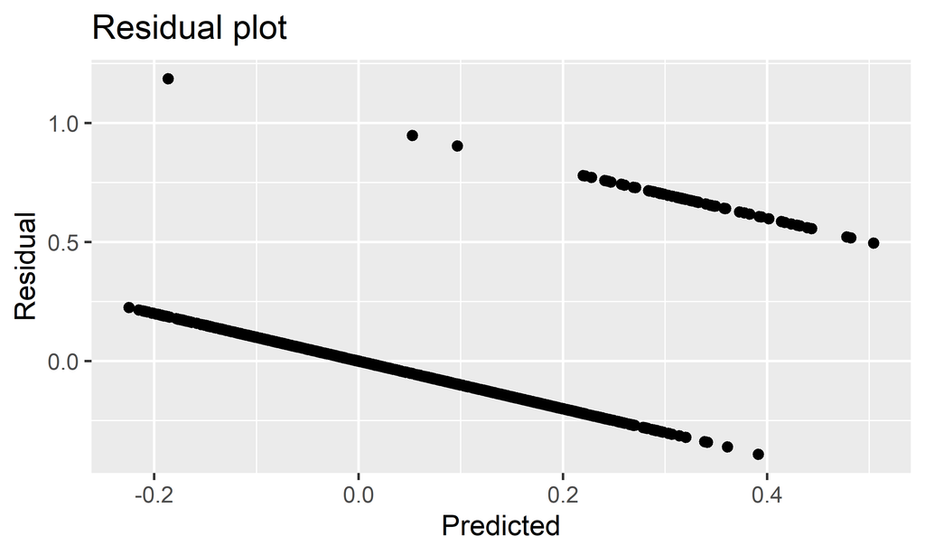

```r
library(broom)
pokemon <- pokemon %>%
  mutate(leg_bin = if_else(legendary == "Yes", 1, 0))
m2 <- lm(leg_bin~hp + atk + def + spa + spd + spe, data = pokemon)

ggplot(data = augment(m2), aes(x = .fitted, y = .resid)) +
  geom_point() +
  labs(x = "Predicted", y = "Residual", title = "Residual plot")
```

We see that the linear model assumptions are definitely not satisfied. Also, looking at the predicted values, many of the Pokemon are predicted to have *negative* probabilities of being legendary (which doesn’t make sense at all!). Similarly, it’s possible to get predicted probabilities greater than 1 in such a linear probability model.

The following histogram of predicted values drives home this point:

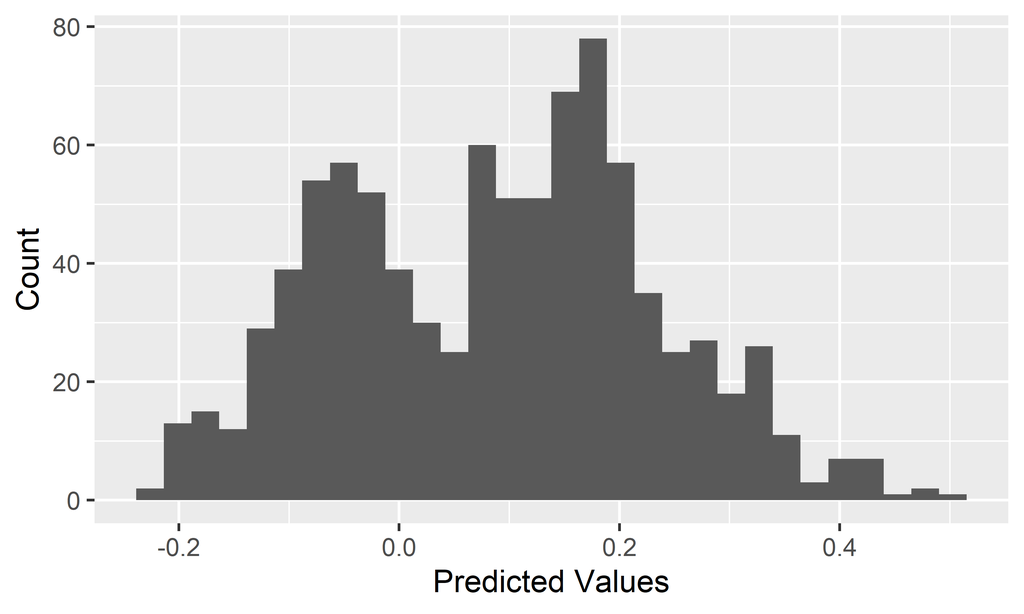

```r
ggplot(data = augment(m2), aes(x = .fitted)) +
  geom_histogram() +
  labs(x = "Predicted Values", y = "Count")
```

## Introducing log-odds

We see that a major problem with a linear model is the fact that linear models can predict any value from $-\infty$ to $\infty$, but probabilities are restricted to lie between 0 and 1. Is there a way to create a model for a *transformation* of the probabilitiy in a principled way such that it’s not a problem if we make predictions that can take on any value?

Suppose the probability of an event is $p$ Then the **odds** that the event occurs is $\frac{p}{1-p}$. Taking the natural log of the odds, we have the **logit** (or log-odds) of $p$:
$$logit(p) = \log\left(\frac{p}{1-p}\right)$$
Note that in statistics, when we say “log” we always mean a logarithm with the natural base $e$. By taking this **logit transformation**, although $p$ is constrained tolie within 0 and 1, $logit(p)$ can range from $-\infty$ to $\infty$.

## Logistic regression

Let’s instead consider the following linear model for the log-odds of $p$:

$${logit(p)} = \beta_0 + \beta_1\times HP + \beta_2\times ATK + \cdots + \beta_6\times SPE$$

Since there is a one-to-one relationship between probabilities and log-odds, we can undo the previous function. If we create a linear model on the **log-odds**, we can “work backwards” to obtain predicted probabilities that are guaranteed to lie between 0 and 1. To “work backwards,” we use the **logistic function**:

$$f(x) = \frac{1}{1 + e^{-x}} = \frac{e^x}{1 + e^x}$$

So, our *linear* model for $logit(p)$ is equivalent to

$$p = \frac{e^{\beta_0 + \beta_1HP + \beta_2ATK + \cdots + \beta_6SPE}}{1 + e^{\beta_0 + \beta_1\times HP + \beta_2\times ATK + \cdots + \beta_6\times SPE}}$$

## Model fitting

We fit the logistic regression model using the `glm` function, which stands for generalized linear model. We need to additionally tell R that we want a logistic model, and so we include the argument `family = "binomial"`. Let’s fit the model and look at the output:

```r
logit_mod <- glm(leg_bin ~ hp + atk + def + spa + spd + spe, data = pokemon,
                 family = "binomial")
tidy(logit_mod)
```

```
## # A tibble: 7 x 5
##   term        estimate std.error statistic  p.value
##   <chr>          <dbl>     <dbl>     <dbl>    <dbl>
## 1 (Intercept) -26.2      2.65        -9.87 5.63e-23
## 2 hp            0.0447   0.00889      5.03 4.92e- 7
## 3 atk           0.0228   0.00839      2.72 6.44e- 3
## 4 def           0.0578   0.00910      6.35 2.21e-10
## 5 spa           0.0492   0.00849      5.79 7.11e- 9
## 6 spd           0.0406   0.00829      4.90 9.57e- 7
## 7 spe           0.0599   0.00964      6.21 5.34e-10
```

We have a *linear* model on a transformation of the response. Thus, we can interpret estimated coefficients analogously to what we’ve learned before for linear models:

Holding all other predictors constant, for each unit increase in base speed, we expect the log-odds of being legendary to increase by 0.06. If we exponentiate this, then we have the multiplicative effect on the **odds** scale (instead of the additive effect on the log-odds scale). Thus, an equivalent interpretation might be that a Pokemon that has a base speed one unit larger than another would have exp(0.06) $\approx$ 1.062 times the *odds* of being legendary.

2. How might we interpret dummy variables for categorical predictors?

We can also use familiar functions from `augment` to create predicted probabilities. In general, we can use our model to predict the log-odds of an event’s occurrence. We can then back-transform in order to obtain the predicted probatilities by instituting a cut-off value (say, if the probability is greater than 0.5).

Take a look at the following code, which will classify the four hypothetical Pokemon above as being legendary or not, based on their base stats:

```r
new_pokemon <- tibble(hp = c(55, 90, 91, 104),
                      atk = c(25, 110, 134, 125),
                      def = c(30, 130, 95, 105),
                      spa = c(60, 75, 100, 148),
                      spd = c(50, 80, 100, 102),
                      spe = c(102, 45, 80, 136))

pred_log_odds <- augment(logit_mod, newdata = new_pokemon) %>%
  pull(.fitted)
```

Let’s work backwards to get predicted probabilities

```r
pred_probs <- exp(pred_log_odds)/(1 + exp(pred_log_odds))
round(pred_probs, 3)
```

```
## [1] 0.000 0.076 0.553 0.999
```

3. What can we conclude given these predicted probabilities?